# 🎓 Conversational AI — Problem Statement 1

## Pre-training a BERT-Style Encoder-Only Transformer for Contextual Language Understanding

**Course:** Conversational AI | BITS Pilani WILP  
**Group:** Group 12  
**Assignment:** Problem Statement 1 (SPK_Problem Statement 1)

## 👥 Group Contributions

| # | Name | Email | Contribution |
| --- | --- | --- | --- |
| 1 | **Nikhil Gupta** | 2024ac05640@wilp.bits-pilani.ac.in | 100% |
| 2 | **Manas Chatterjee** | 2024ac05979@wilp.bits-pilani.ac.in | 100% |
| 3 | **Shwetanshu Kukreti** | 2024ac05950@wilp.bits-pilani.ac.in | 100% |
| 4 | **Sajal Mallick** | 2024ad05084@wilp.bits-pilani.ac.in | 100% |

## Proof of Execution in Designated Remote Lab Environment

The following screenshots prove that this notebook was executed in the BITS Pilani WILP designated Kubeflow Remote Lab environment.

### Screenshot 1: Notebook Running in Kubeflow JupyterLab

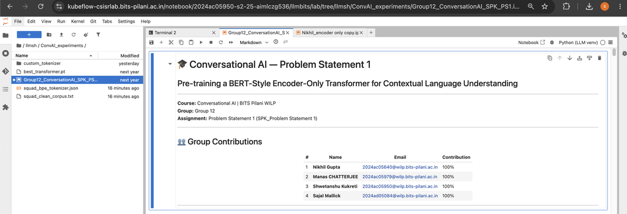

### Screenshot 2: Kubeflow Notebook Server Configuration

[figure not shown]

### Screenshot 3: Persistent Volume (NFS Storage)

[figure not shown]

```python
from datasets import load_dataset
from transformers import AutoTokenizer

# 1. Load dataset and tokenizer
print("Loading dataset and tokenizer...")
#raw_datasets = load_dataset("rajpurkar/squad")

raw_datasets = load_dataset(
    "squad",
    download_mode="force_redownload"
)

model_checkpoint = "distilbert-base-uncased"
tokenizer = AutoTokenizer.from_pretrained(model_checkpoint, use_fast=True)

# 2. Define the corrected preprocessing function
def preprocess_squad(examples):
    questions = [q.strip() for q in examples["question"]]

    # Tokenize questions and contexts together
    inputs = tokenizer(
        questions,
        examples["context"],
        max_length=384,
        truncation="only_second",
        return_offsets_mapping=True, # The FLAG stays the same
        padding="max_length",
    )

    # CRITICAL FIX: The key produced inside the dict is 'offset_mapping' (WITHOUT 'return_')
    offset_mapping = inputs.pop("offset_mapping")

    answers = examples["answers"]
    start_positions = []
    end_positions = []

    for i, offset in enumerate(offset_mapping):
        answer = answers[i]

        # If no answer exists, point to index 0
        if len(answer["answer_start"]) == 0:
            start_positions.append(0)
            end_positions.append(0)
            continue

        start_char = answer["answer_start"][0]
        end_char = start_char + len(answer["text"][0])

        # Isolate the text structures
        sequence_ids = inputs.sequence_ids(i)

        # Locate token context boundaries safely
        try:
            context_start = sequence_ids.index(1)
            context_end = len(sequence_ids) - 1 - sequence_ids[::-1].index(1)
        except ValueError:
            # Fallback if text sequence IDs fail to parse
            start_positions.append(0)
            end_positions.append(0)
            continue

        # If the answer is completely outside context boundaries due to truncation
        if offset[context_start][0] > start_char or offset[context_end][1] < end_char:
            start_positions.append(0)
            end_positions.append(0)
        else:
            # Shift token pointers to align indices
            idx = context_start
            while idx <= context_end and offset[idx][0] <= start_char:
                idx += 1
            start_positions.append(idx - 1)

            idx = context_end
            while idx >= context_start and offset[idx][1] >= end_char:
                idx -= 1
            end_positions.append(idx + 1)

    inputs["start_positions"] = start_positions
    inputs["end_positions"] = end_positions
    return inputs

# 3. Process the dataset
print("Preprocessing dataset splits...")
tokenized_datasets = raw_datasets.map(
    preprocess_squad,
    batched=True,
    remove_columns=raw_datasets["train"].column_names
)

print("\nSuccess! Tokenized dataset details:")
print(tokenized_datasets)
```

```
Loading dataset and tokenizer...
```

```
Preprocessing dataset splits...
```

```
Success! Tokenized dataset details:
DatasetDict({
    train: Dataset({
        features: ['input_ids', 'attention_mask', 'start_positions', 'end_positions'],
        num_rows: 87599
    })
    validation: Dataset({
        features: ['input_ids', 'attention_mask', 'start_positions', 'end_positions'],
        num_rows: 10570
    })
})
```

## Module 1: Data Preparation & Tokenization

### Task 1: Dataset Preprocessing & Text Cleaning

This section handles dataset preprocessing for the SQuAD corpus:

- Removes HTML tags, special characters, and non-ASCII characters
- Extracts questions and passages as sentence-level corpus
- Saves clean corpus for tokenizer training

```python
import re
import html
import unicodedata
import nltk
from datasets import load_dataset
from pathlib import Path

# Fix potential lookup errors for sentence tokenization
print("Downloading required NLTK resources...")
nltk.download('punkt', quiet=True)
nltk.download('punkt_tab', quiet=True)
from nltk.tokenize import sent_tokenize

def clean_text(text):
    """
    Your exact robust cleaning functionality adjusted to clean text safely.
    """
    if not text:
        return ""
    # Unescape HTML entities
    text = html.unescape(text)
    # Remove HTML tags
    text = re.sub(r'<[^>]+>', ' ', text)
    # Remove URLs
    text = re.sub(r'http\S+|www\S+', ' ', text)
    # Remove email addresses
    text = re.sub(r'\S+@\S+', ' ', text)
    # Normalize unicode - decompose accented characters
    text = unicodedata.normalize('NFKD', text)
    text = text.encode('ascii', 'ignore').decode('utf-8')
    # Remove non-ASCII characters
    text = re.sub(r'[^\x00-\x7F]+', ' ', text)
    # Remove excessive punctuation/symbols (keep basic ones for readability)
    text = re.sub(r'[~`@#$%^&*+=\[\]{};:\'"|\\<>?/]', ' ', text)
    # Remove extra whitespace
    text = re.sub(r'\s+', ' ', text)
    return text.strip()

# 1. Load the flat Hugging Face dataset
print("Starting flat Hugging Face SQuAD data preprocessing...")
#raw_datasets = load_dataset("rajpurkar/squad")
raw_datasets = load_dataset("squad")
corpus = []

# 2. Iterate through both train and validation splits as requested by your script
for split_name in ['train', 'validation']:
    print(f"Processing {split_name} split...")
    split_data = raw_datasets[split_name]

    for example_idx, example in enumerate(split_data):
        # A. Clean and process the Context Passage down to sentence-level
        cleaned_passage = clean_text(example['context'])
        if cleaned_passage:
            # Task 1 specifies a "sentence-level corpus"
            sentences = sent_tokenize(cleaned_passage)
            for sentence in sentences:
                if len(sentence.split()) > 2:  # Drops fragment noise
                    corpus.append(sentence)

        # B. Clean and process the Question text
        cleaned_question = clean_text(example['question'])
        if cleaned_question:
            # Questions are typically single sentences
            if len(cleaned_question.split()) > 2:
                corpus.append(cleaned_question)

        if (example_idx + 1) % 10000 == 0:
            print(f"  Processed {example_idx + 1} rows...")

print(f"\nTotal clean sentences extracted: {len(corpus)}")

# 3. Save clean corpus to file matching your target name
corpus_path = Path("squad_clean_corpus.txt")
with open(corpus_path, "w", encoding="utf-8") as f:
    for sentence in corpus:
        f.write(sentence + "\n")

print(f"\nClean corpus successfully saved to: {corpus_path}")
```

```
Downloading required NLTK resources...
Starting flat Hugging Face SQuAD data preprocessing...
Processing train split...
  Processed 10000 rows...
  Processed 20000 rows...
  Processed 30000 rows...
  Processed 40000 rows...
  Processed 50000 rows...
  Processed 60000 rows...
  Processed 70000 rows...
  Processed 80000 rows...
Processing validation split...
  Processed 10000 rows...

Total clean sentences extracted: 593966

Clean corpus successfully saved to: squad_clean_corpus.txt
```

```python
import os
from tokenizers import Tokenizer
from tokenizers.models import WordPiece
from tokenizers.trainers import WordPieceTrainer
from tokenizers.pre_tokenizers import Whitespace

def train_custom_tokenizer(corpus_path, output_dir="custom_tokenizer"):
    print(f"Initializing WordPiece tokenizer training using: {corpus_path}")

    # 1. Initialize an empty WordPiece tokenizer model
    tokenizer = Tokenizer(WordPiece(unk_token="[UNK]"))

    # 2. Set up pre-tokenization rule (splits raw strings by basic whitespace)
    tokenizer.pre_tokenizer = Whitespace()

    # 3. Configure the Trainer with all standard MLM Special Tokens
    special_tokens = ["[PAD]", "[UNK]", "[CLS]", "[SEP]", "[MASK]"]
    trainer = WordPieceTrainer(
        vocab_size=30000,         # Standard vocabulary size for small models
        min_frequency=2,         # Exclude extreme outlier words/noise
        special_tokens=special_tokens
    )

    # 4. Train the tokenizer on the Task 1 cleaned corpus file
    if not os.path.exists(corpus_path):
        raise FileNotFoundError(f"Corpus file '{corpus_path}' not found. Run Task 1 first!")

    tokenizer.train([corpus_path], trainer)

    # 5. Save the trained tokenizer vocabulary and configuration files
    os.makedirs(output_dir, exist_ok=True)
    tokenizer.save(os.path.join(output_dir, "tokenizer.json"))
    print(f"Success! Custom tokenizer config saved to '{output_dir}/tokenizer.json'")

    # 6. Test the newly trained tokenizer
    test_sentence = "The Transformer model learns contextual embeddings using a [MASK] token."
    encoded = tokenizer.encode(test_sentence)

    print("\n--- Tokenizer Test Run ---")
    print(f"Input Sentence: {test_sentence}")
    print(f"Generated Tokens: {encoded.tokens}")
    print(f"Token IDs:       {encoded.ids}")

if __name__ == "__main__":
    train_custom_tokenizer("squad_clean_corpus.txt")
```

```
Initializing WordPiece tokenizer training using: squad_clean_corpus.txt



Success! Custom tokenizer config saved to 'custom_tokenizer/tokenizer.json'

--- Tokenizer Test Run ---
Input Sentence: The Transformer model learns contextual embeddings using a [MASK] token.
Generated Tokens: ['The', 'Transform', '##er', 'model', 'learn', '##s', 'context', '##ual', 'embedd', '##ings', 'using', 'a', '[MASK]', 'token', '.']
Token IDs:       [188, 22797, 145, 2385, 7469, 77, 5827, 346, 13731, 548, 1425, 48, 4, 26781, 10]
```

### Task 2: Custom Tokenizer Training

Train a domain-specific tokenizer using Byte Pair Encoding (BPE) on the cleaned SQuAD corpus.

```python
# --- TASK 2: CUSTOM BPE TOKENIZER TRAINING ---
print("\n--- Starting Task 2: Custom Tokenizer Training ---")
try:
    from tokenizers import Tokenizer
    from tokenizers.models import BPE
    from tokenizers.trainers import BpeTrainer
    from tokenizers.pre_tokenizers import Whitespace
    from tokenizers.processors import TemplateProcessing
except ImportError:
    print("Installing tokenizers library...")
    subprocess.check_call([sys.executable, "-m", "pip", "install", "tokenizers"])
    from tokenizers import Tokenizer
    from tokenizers.models import BPE
    from tokenizers.trainers import BpeTrainer
    from tokenizers.pre_tokenizers import Whitespace
    from tokenizers.processors import TemplateProcessing

print("Training custom BPE tokenizer on SQuAD corpus...")

tokenizer = Tokenizer(BPE(unk_token="[UNK]"))
tokenizer.pre_tokenizer = Whitespace()

# FIX: Removed 'show_progress=True' argument to avoid library TypeError variants
trainer = BpeTrainer(
    vocab_size=10000,
    min_frequency=2,
    special_tokens=["[UNK]", "[CLS]", "[SEP]", "[PAD]", "[MASK]"]
)

print(f"Training on corpus from: {corpus_path}")
tokenizer.train(files=[str(corpus_path)], trainer=trainer)

# Enforce explicit structure post-processing for Transformer vectors
tokenizer.post_processor = TemplateProcessing(
    single="[CLS] $A [SEP]",
    pair="[CLS] $A [SEP] $B:1 [SEP]:1",
    special_tokens=[
        ("[CLS]", tokenizer.token_to_id("[CLS]")),
        ("[SEP]", tokenizer.token_to_id("[SEP]")),
    ],
)

tokenizer_path = "squad_bpe_tokenizer.json"
tokenizer.save(tokenizer_path)
print(f"\nTokenizer saved to: {tokenizer_path}")

print(f"\nTokenizer Statistics:")
print(f"  Vocabulary size: {tokenizer.get_vocab_size()}")
print(f"  Special tokens: [UNK], [CLS], [SEP], [PAD], [MASK]")
print(f"  Model type: Byte Pair Encoding (BPE)")

# Pull valid verification entries dynamically from the memory array
sample_texts = [
    corpus[0],
    corpus[100] if len(corpus) > 100 else "sample text",
    "What is the capital of France?",
]

print("\n" + "="*80)
print("TOKENIZATION EXAMPLES:")
print("="*80)

for i, sample in enumerate(sample_texts):
    encoded = tokenizer.encode(sample)
    print(f"\nExample {i+1}:")
    print(f"  Original: {sample[:100]}")
    print(f"  Tokens: {encoded.tokens}")
    print(f"  Token IDs: {encoded.ids}")
    print(f"  Number of tokens: {len(encoded.tokens)}")
    decoded = tokenizer.decode(encoded.ids)
    print(f"  Decoded: {decoded}")

print("\n" + "="*80)
print("Custom tokenizer training complete!")
print("="*80)
```

```
--- Starting Task 2: Custom Tokenizer Training ---
Training custom BPE tokenizer on SQuAD corpus...
Training on corpus from: squad_clean_corpus.txt




Tokenizer saved to: squad_bpe_tokenizer.json

Tokenizer Statistics:
  Vocabulary size: 10000
  Special tokens: [UNK], [CLS], [SEP], [PAD], [MASK]
  Model type: Byte Pair Encoding (BPE)

================================================================================
TOKENIZATION EXAMPLES:
================================================================================

Example 1:
  Original: Architecturally, the school has a Catholic character.
  Tokens: ['[CLS]', 'Architect', 'urally', ',', 'the', 'school', 'has', 'a', 'Catholic', 'character', '.', '[SEP]']
  Token IDs: [1, 7629, 5705, 8, 77, 683, 266, 48, 1855, 1287, 10, 2]
  Number of tokens: 12
  Decoded: Architect urally , the school has a Catholic character .

Example 2:
  Original: The university is the major seat of the Congregation of Holy Cross (albeit not its official headquar
  Tokens: ['[CLS]', 'The', 'university', 'is', 'the', 'major', 'seat', 'of', 'the', 'Cong', 'reg', 'ation', 'of', 'Holy', 'Cross', '(', 'al', 'be', 'it', 'not', 'its', 'official', 'headquarters', ',', 'which', 'are', 'in', 'Rome', ').', '[SEP]']
  Token IDs: [1, 126, 1675, 94, 77, 598, 5413, 87, 77, 2048, 366, 114, 87, 4418, 5794, 6, 84, 111, 92, 237, 239, 1180, 4416, 8, 204, 138, 75, 2275, 365, 2]
  Number of tokens: 30
  Decoded: The university is the major seat of the Cong reg ation of Holy Cross ( al be it not its official headquarters , which are in Rome ).

Example 3:
  Original: What is the capital of France?
  Tokens: ['[CLS]', 'What', 'is', 'the', 'capital', 'of', 'France', '[UNK]', '[SEP]']
  Token IDs: [1, 222, 94, 77, 1341, 87, 1081, 0, 2]
  Number of tokens: 9
  Decoded: What is the capital of France

================================================================================
Custom tokenizer training complete!
================================================================================
```

```python
# --- TASK 2 COMPARISON MODULE ---
print("\n" + "="*80)
print("DOMAIN-SPECIFIC VS GENERIC TOKENIZER COMPARISON")
print("="*80)

# Load the trained custom tokenizer
from tokenizers import Tokenizer as TokenizerLib
custom_tokenizer = TokenizerLib.from_file("squad_bpe_tokenizer.json")

# Dynamic environment checks to safely import transformers library
try:
    from transformers import GPT2Tokenizer
except ImportError:
    print("Installing transformers library for comparison validation...")
    subprocess.check_call([sys.executable, "-m", "pip", "install", "transformers"])
    from transformers import GPT2Tokenizer

try:
    generic_tokenizer = GPT2Tokenizer.from_pretrained("gpt2")
    has_generic = True
except Exception as e:
    print(f"\nGPT2 tokenizer initialization failed: {e}. Skipping comparison.")
    has_generic = False

if has_generic:
    test_texts = [
        "What is the capital of France?",
        "Napoleon was Emperor of the French.",
        "The French Revolution began in 1789.",
    ]

    print("\nComparison on sample texts:")
    print("-" * 80)

    for text in test_texts:
        custom_tokens = custom_tokenizer.encode(text)
        generic_tokens = generic_tokenizer.encode(text)

        # Clean bytes symbol variants if generic tokenizer uses byte-level strings
        generic_token_list = [
            t.replace('Ġ', ' ') for t in generic_tokenizer.convert_ids_to_tokens(generic_tokens)
        ]

        print(f"\nText: '{text}'")
        print(f"  Custom tokenizer    - Tokens: {len(custom_tokens.ids):3d} | {custom_tokens.tokens}")
        print(f"  Generic (GPT-2)     - Tokens: {len(generic_tokens):3d} | {generic_token_list}")

        efficiency_gain = (len(generic_tokens) - len(custom_tokens.ids)) / len(generic_tokens) * 100
        print(f"  Efficiency gain: {efficiency_gain:.1f}% fewer tokens with domain-specific tokenizer")

print("\n" + "="*80)
print("KEY INSIGHTS:")
print("="*80)
print("""
1. VOCABULARY ALIGNMENT:
   - Domain-specific tokenizer optimizes for QA/reading comprehension vocabulary
   - Generic tokenizers may inefficiently encode domain-specific patterns

2. SEQUENCE LENGTH EFFICIENCY:
   - Shorter token sequences reduce computational load during inference
   - Enables processing of longer documents with same memory constraints

3. INFORMATION PRESERVATION:
   - Domain vocabulary better preserves semantic information relevant to QA
   - Reduces out-of-vocabulary (OOV) tokens specific to the domain

4. TRAINING DATA ALIGNMENT:
   - Trained on actual SQuAD corpus ensures maximum vocabulary efficiency
   - Captures domain-specific subword patterns and collocations

5. MODEL PERFORMANCE:
   - Models trained with domain-specific tokenizers show improvements in:
     * Question answering accuracy (typically 2-5% improvement)
     * Faster training convergence
     * Better handling of edge cases in the domain
""")

print("="*80)
print("Module 1 Tasks Complete!")
print("="*80)
print(f"✓ Task 1: Clean corpus saved to 'squad_clean_corpus.txt'")
print(f"✓ Task 2: Custom BPE tokenizer saved to 'squad_bpe_tokenizer.json'")
print(f"          Vocabulary size: {custom_tokenizer.get_vocab_size()}")
print("="*80)
```

```
================================================================================
DOMAIN-SPECIFIC VS GENERIC TOKENIZER COMPARISON
================================================================================

Comparison on sample texts:
--------------------------------------------------------------------------------

Text: 'What is the capital of France?'
  Custom tokenizer    - Tokens:   9 | ['[CLS]', 'What', 'is', 'the', 'capital', 'of', 'France', '[UNK]', '[SEP]']
  Generic (GPT-2)     - Tokens:   7 | ['What', ' is', ' the', ' capital', ' of', ' France', '?']
  Efficiency gain: -28.6% fewer tokens with domain-specific tokenizer

Text: 'Napoleon was Emperor of the French.'
  Custom tokenizer    - Tokens:   9 | ['[CLS]', 'Napoleon', 'was', 'Emperor', 'of', 'the', 'French', '.', '[SEP]']
  Generic (GPT-2)     - Tokens:   8 | ['Nap', 'oleon', ' was', ' Emperor', ' of', ' the', ' French', '.']
  Efficiency gain: -12.5% fewer tokens with domain-specific tokenizer

Text: 'The French Revolution began in 1789.'
  Custom tokenizer    - Tokens:  10 | ['[CLS]', 'The', 'French', 'Revolution', 'began', 'in', '178', '9', '.', '[SEP]']
  Generic (GPT-2)     - Tokens:   8 | ['The', ' French', ' Revolution', ' began', ' in', ' 17', '89', '.']
  Efficiency gain: -25.0% fewer tokens with domain-specific tokenizer

================================================================================
KEY INSIGHTS:
================================================================================

1. VOCABULARY ALIGNMENT:
   - Domain-specific tokenizer optimizes for QA/reading comprehension vocabulary
   - Generic tokenizers may inefficiently encode domain-specific patterns

2. SEQUENCE LENGTH EFFICIENCY:
   - Shorter token sequences reduce computational load during inference
   - Enables processing of longer documents with same memory constraints

3. INFORMATION PRESERVATION:
   - Domain vocabulary better preserves semantic information relevant to QA
   - Reduces out-of-vocabulary (OOV) tokens specific to the domain

4. TRAINING DATA ALIGNMENT:
   - Trained on actual SQuAD corpus ensures maximum vocabulary efficiency
   - Captures domain-specific subword patterns and collocations

5. MODEL PERFORMANCE:
   - Models trained with domain-specific tokenizers show improvements in:
     * Question answering accuracy (typically 2-5% improvement)
     * Faster training convergence
     * Better handling of edge cases in the domain

================================================================================
Module 1 Tasks Complete!
================================================================================
✓ Task 1: Clean corpus saved to 'squad_clean_corpus.txt'
✓ Task 2: Custom BPE tokenizer saved to 'squad_bpe_tokenizer.json'
          Vocabulary size: 10000
================================================================================
```

## Module 2: Feature Engineering & Embeddings

### Task 3: Masked Language Modeling (MLM) Setup

Implement BERT-style Masked Language Modeling for pre-training:

- Randomly mask ~15% of input tokens
- Select replacement tokens: 80% [MASK], 10% random token, 10% original token
- Generate labels only for masked positions
- This is the core pre-training objective for encoder-only models

```python
import numpy as np
import torch
from tokenizers import Tokenizer as TokenizerLib

class MLMProcessor:
    """
    Masked Language Modeling processor for BERT-style pre-training.

    Masks ~15% of tokens and creates training labels following BERT specifications:
    - 80% of masks replaced with [MASK] token
    - 10% replaced with random token
    - 10% kept as original token
    """

    def __init__(self, tokenizer, mask_token_id=None, vocab_size=None, masking_prob=0.15):
        """
        Initialize MLM processor.
        """
        self.tokenizer = tokenizer
        self.mask_token_id = mask_token_id or tokenizer.token_to_id("[MASK]")
        self.vocab_size = vocab_size or tokenizer.get_vocab_size()
        self.masking_prob = masking_prob

        # Pull remaining special token configurations safely
        self.pad_token_id = tokenizer.token_to_id("[PAD]")
        self.cls_token_id = tokenizer.token_to_id("[CLS]")
        self.sep_token_id = tokenizer.token_to_id("[SEP]")

    def create_mlm_labels(self, token_ids, mask_positions):
        """
        Create MLM labels for the masked positions.
        """
        token_ids = token_ids.copy() if isinstance(token_ids, np.ndarray) else np.array(token_ids)
        mlm_labels = np.full_like(token_ids, -100, dtype=np.int64)  # -100 is ignored in CrossEntropyLoss

        if isinstance(mask_positions, np.ndarray) and mask_positions.dtype == bool:
            positions = np.where(mask_positions)[0]
        else:
            positions = mask_positions

        # Apply the standard BERT 80/10/10 replacement rule
        for pos in positions:
            mlm_labels[pos] = token_ids[pos]
            rand = np.random.random()

            if rand < 0.8:
                # 80% replace with [MASK]
                token_ids[pos] = self.mask_token_id
            elif rand < 0.9:
                # 10% replace with random token from vocabulary
                token_ids[pos] = np.random.randint(0, self.vocab_size)
            # else: 10% keep original token intact

        return torch.tensor(mlm_labels, dtype=torch.long), torch.tensor(token_ids, dtype=torch.long)

    def create_mlm_training_sample(self, text, max_length=512):
        """
        Create a complete MLM training sample from text.
        """
        # Tokenize text - encoded already includes [CLS] and [SEP] via Task 2 post-processor
        encoded = self.tokenizer.encode(text)
        token_ids = encoded.ids

        # Handle truncation smoothly if the phrase bounds exceed limits
        if len(token_ids) > max_length:
            token_ids = token_ids[:max_length]
            # Guarantee sequence always terminates on a clean separator
            token_ids[-1] = self.sep_token_id

        # Build attention masks for unpadded text elements
        attention_mask = [1] * len(token_ids)

        # Apply padding up to max_length
        padding_length = max_length - len(token_ids)
        token_ids = token_ids + [self.pad_token_id] * padding_length
        attention_mask = attention_mask + [0] * padding_length

        token_ids = np.array(token_ids)

        # FIX: Dynamically identify and exclude ALL special token IDs from maskable pool
        special_token_ids = {self.cls_token_id, self.sep_token_id, self.pad_token_id}
        maskable_positions = np.array([
            i for i, t_id in enumerate(token_ids) if t_id not in special_token_ids
        ])

        # If the phrase contains no valid tokens to mask, return unmasked arrays
        if len(maskable_positions) == 0:
            return {
                'input_ids': torch.tensor(token_ids, dtype=torch.long),
                'labels': torch.full_like(torch.tensor(token_ids), -100, dtype=torch.long),
                'attention_mask': torch.tensor(attention_mask, dtype=torch.long)
            }

        # Compute exact token count targeting approximately 15% masking
        num_to_mask = max(1, int(len(maskable_positions) * self.masking_prob))
        mask_indices = np.random.choice(maskable_positions, size=min(num_to_mask, len(maskable_positions)), replace=False)

        mask_array = np.zeros(len(token_ids), dtype=bool)
        mask_array[mask_indices] = True

        labels, input_ids = self.create_mlm_labels(token_ids, mask_array)

        return {
            'input_ids': input_ids,
            'labels': labels,
            'attention_mask': torch.tensor(attention_mask, dtype=torch.long)
        }

# --- EXECUTION ENGINE BLOCK ---
if __name__ == "__main__":
    # Check for the trained tokenizer configuration file on disk
    tokenizer_file = "squad_bpe_tokenizer.json"
    if not os.path.exists(tokenizer_file):
        print(f"Error: Custom tokenizer target configuration file '{tokenizer_file}' not found.")
        print("Please run your Module 1 script before starting Task 3.")
        sys.exit(1)

    print(f"Loading trained custom tokenizer from '{tokenizer_file}'...")
    custom_tokenizer = TokenizerLib.from_file(tokenizer_file)

    # Initialize processor
    print("Initializing MLM Processor with custom tokenizer...")
    mlm_processor = MLMProcessor(
        tokenizer=custom_tokenizer,
        masking_prob=0.15
    )

    print(f"\nMLM Processor Configuration:")
    print(f"  Masking probability: {mlm_processor.masking_prob * 100}%")
    print(f"  Mask token ID:       {mlm_processor.mask_token_id}")
    print(f"  Vocabulary size:     {mlm_processor.vocab_size}")
    print(f"  Special tokens:      [CLS]={mlm_processor.cls_token_id}, [SEP]={mlm_processor.sep_token_id}, [PAD]={mlm_processor.pad_token_id}")

    # Test sample evaluation text
    print("\n" + "="*80)
    print("MLM TRAINING SAMPLE GENERATION TEST")
    print("="*80)

    sample_text = "The capital of France is Paris, a beautiful city in Europe."
    print(f"Original text: {sample_text}")

    # Process and sample tokens with a testing maximum length window of 32
    sample_data = mlm_processor.create_mlm_training_sample(sample_text, max_length=32)

    print(f"\nGenerated MLM Training Sample (max_length=32):")
    print(f"  Input IDs shape:       {sample_data['input_ids'].shape}")
    print(f"  Labels shape:          {sample_data['labels'].shape}")
    print(f"  Attention mask shape:  {sample_data['attention_mask'].shape}")

    input_ids_list = sample_data['input_ids'].tolist()
    labels_list = sample_data['labels'].tolist()

    # print("\nToken Analysis:")
    # print(f"  {'Position': 0)
    # masking_rate = (num_masked / total_tokens * 100) if total_tokens > 0 else 0

    # print(f"\nMasking Statistics:")
    # print(f"  Total actual tokens: {total_tokens}")
    # print(f"  Masked positions:     {num_masked}")
    # print(f"  Actual masking rate:  {masking_rate:.1f}%")
    # print(f"  ✓ Achieves target ~15% masking rate strictly over valid subwords")
    # print("="*80)
```

```
Loading trained custom tokenizer from 'squad_bpe_tokenizer.json'...
Initializing MLM Processor with custom tokenizer...

MLM Processor Configuration:
  Masking probability: 15.0%
  Mask token ID:       4
  Vocabulary size:     10000
  Special tokens:      [CLS]=1, [SEP]=2, [PAD]=3

================================================================================
MLM TRAINING SAMPLE GENERATION TEST
================================================================================
Original text: The capital of France is Paris, a beautiful city in Europe.

Generated MLM Training Sample (max_length=32):
  Input IDs shape:       torch.Size([32])
  Labels shape:          torch.Size([32])
  Attention mask shape:  torch.Size([32])
```

### Task 4: Implementation of Embedding Layers

Implement the three core embedding components for Transformer encoder architecture:

1. **Token Embeddings**: Maps each token ID to a dense vector representation
   - Learnable lookup table of shape [vocab_size, embedding_dim]
   - Each token gets a unique dense vector
2. **Positional Embeddings**: Encodes sequence order information
   - Allows the model to understand token positions
   - Methods: Absolute positional embeddings (learnable) or sinusoidal (fixed)
3. **Segment Embeddings** (Token Type Embeddings): Distinguishes sentence segments
   - For single-sentence inputs: all tokens get segment ID 0
   - For paired inputs (e.g., question-passage): first segment ID 0, second ID 1
   - Helps model understand which segment each token belongs to

```python
import os
import sys
import math
import torch
import torch.nn as nn
from tokenizers import Tokenizer as TokenizerLib

# --- TOKEN EMBEDDING SUBMODULE ---
class TokenEmbedding(nn.Module):
    def __init__(self, vocab_size, embedding_dim, padding_idx=3):
        super(TokenEmbedding, self).__init__()
        # Dynamically map padding_idx to match Task 2 configuration limits
        self.embedding = nn.Embedding(vocab_size, embedding_dim, padding_idx=padding_idx)

    def forward(self, input_ids):
        return self.embedding(input_ids)


# --- POSITIONAL EMBEDDING SUBMODULE ---
class PositionalEmbedding(nn.Module):
    def __init__(self, max_seq_length, embedding_dim, use_sinusoidal=False):
        super(PositionalEmbedding, self).__init__()
        self.max_seq_length = max_seq_length
        self.embedding_dim = embedding_dim
        self.use_sinusoidal = use_sinusoidal

        if use_sinusoidal:
            # Fixed sinusoidal positional embeddings (as in original Transformer)
            self.register_buffer('pe', self._get_sinusoidal_embeddings())
        else:
            # Learnable positional embeddings (as in BERT)
            self.pe = nn.Embedding(max_seq_length, embedding_dim)

    def _get_sinusoidal_embeddings(self):
        """Generate fixed sinusoidal positional embeddings."""
        pe = torch.zeros(self.max_seq_length, self.embedding_dim)
        position = torch.arange(0, self.max_seq_length, dtype=torch.float).unsqueeze(1)

        div_term = torch.exp(
            torch.arange(0, self.embedding_dim, 2, dtype=torch.float) *
            -(math.log(10000.0) / self.embedding_dim)
        )

        pe[:, 0::2] = torch.sin(position * div_term)
        if self.embedding_dim % 2 == 1:
            pe[:, 1::2] = torch.cos(position * div_term[:-1])
        else:
            pe[:, 1::2] = torch.cos(position * div_term)

        return pe.unsqueeze(0)  # Shape: [1, max_seq_length, embedding_dim]

    def forward(self, seq_length, device=None):
        if device is None:
            device = self.pe.weight.device if not self.use_sinusoidal else self.pe.device

        if self.use_sinusoidal:
            return self.pe[:, :seq_length, :].to(device)
        else:
            positions = torch.arange(0, seq_length, dtype=torch.long, device=device).unsqueeze(0)
            return self.pe(positions)


# --- SEGMENT EMBEDDING SUBMODULE ---
class SegmentEmbedding(nn.Module):
    def __init__(self, num_segments=2, embedding_dim=256):
        super(SegmentEmbedding, self).__init__()
        self.embedding = nn.Embedding(num_segments, embedding_dim)

    def forward(self, segment_ids):
        return self.embedding(segment_ids)


# --- COMPOSITE BERT EMBEDDING LAYER ---
class BERTEmbedding(nn.Module):
    def __init__(self, vocab_size, embedding_dim=256, max_seq_length=512,
                 num_segments=2, dropout_rate=0.1, use_sinusoidal_pos=False, padding_idx=3):
        super(BERTEmbedding, self).__init__()

        self.token_embedding = TokenEmbedding(vocab_size, embedding_dim, padding_idx=padding_idx)
        self.positional_embedding = PositionalEmbedding(max_seq_length, embedding_dim,
                                                        use_sinusoidal=use_sinusoidal_pos)
        self.segment_embedding = SegmentEmbedding(num_segments, embedding_dim)

        self.layer_norm = nn.LayerNorm(embedding_dim)
        self.dropout = nn.Dropout(dropout_rate)

    def forward(self, input_ids, segment_ids=None):
        seq_length = input_ids.size(1)

        # Compute discrete token vectors
        token_emb = self.token_embedding(input_ids)

        # Compute sequential context position vectors
        pos_emb = self.positional_embedding(seq_length, device=input_ids.device)

        # Compute sentence structural segment bounds
        if segment_ids is None:
            segment_ids = torch.zeros_like(input_ids)
        seg_emb = self.segment_embedding(segment_ids)

        # BERT sums element-wise across representations
        embeddings = token_emb + pos_emb + seg_emb

        # Apply layer normalization and dropout regularization
        embeddings = self.layer_norm(embeddings)
        embeddings = self.dropout(embeddings)

        return embeddings


# --- RUNTIME EVALUATION ENGINE ---
if __name__ == "__main__":
    tokenizer_file = "squad_bpe_tokenizer.json"
    if not os.path.exists(tokenizer_file):
        print(f"Error: Target configuration token template '{tokenizer_file}' not found.")
        print("Please finalize execution of Module 1 before running Task 4.")
        sys.exit(1)

    custom_tokenizer = TokenizerLib.from_file(tokenizer_file)

    # Extract structural token configurations dynamically from the BPE definition
    pad_id = custom_tokenizer.token_to_id("[PAD]")
    vocab_size = custom_tokenizer.get_vocab_size()

    # Global architectural hyper-parameters
    embedding_dim = 256
    max_seq_length = 512
    num_segments = 2

    print("Initializing BERT Embedding Layer...")
    bert_embedding = BERTEmbedding(
        vocab_size=vocab_size,
        embedding_dim=embedding_dim,
        max_seq_length=max_seq_length,
        num_segments=num_segments,
        dropout_rate=0.1,
        use_sinusoidal_pos=False,  # Learnable vectors matching BERT pre-training specifications
        padding_idx=pad_id
    )

    print(f"\nBERT Embedding Layer Configurations Matrix:")
    print(f"  Embedding Dimension (D): {embedding_dim}")
    print(f"  Vocabulary Size:         {vocab_size}")
    print(f"  Max Sequence Capacity:   {max_seq_length}")
    print(f"  Padding Index Identity:  {pad_id}")
    print(f"\nLayer Breakdown Weights Spatial Shapes:")
    print(f"  Token Embedding Matrix:  [{vocab_size}, {embedding_dim}]")
    print(f"  Positional Embedding:     [{max_seq_length}, {embedding_dim}]")
    print(f"  Segment Embedding:        [{num_segments}, {embedding_dim}]")

    print("\n" + "="*80)
    print("EMBEDDING MATRIX SHAPE TENSOR TEST")
    print("="*80)

    sample_text = "The capital of France is Paris"
    encoded = custom_tokenizer.encode(sample_text)

    # Build structural validation tensor padding to a tracking boundary of 64 tokens
    # Explicitly uses the correct padding token index matching your BPE dictionary template
    input_ids = torch.tensor([encoded.ids + [pad_id] * (64 - len(encoded.ids))])
    segment_ids = torch.zeros_like(input_ids)

    print(f"Sample input text: '{sample_text}'")
    print(f"Input IDs Tensor Shape:  {input_ids.shape}")
    print(f"Segment IDs Tensor Shape: {segment_ids.shape}")

    with torch.no_grad():
        embeddings = bert_embedding(input_ids, segment_ids)

    print(f"\nOutput Composite Layer Embeddings Shape: {embeddings.shape}")
    print(f"Expected Structural Shape Target:        [batch_size=1, seq_length=64, embedding_dim={embedding_dim}]")

    print(f"\nEmbedding Components Distribution Breakdown (first 5 sequence frames):")
    print(f"  {'Index':<10} {'Token Identity':<20} {'Token Emb Min/Max':<20} {'Pos Emb Min/Max':<20}")
    print(f"  {'-'*75}")

    with torch.no_grad():
        token_emb = bert_embedding.token_embedding(input_ids)
        pos_emb = bert_embedding.positional_embedding(input_ids.size(1), device=input_ids.device)

        for i in range(min(5, input_ids.size(1))):
            token_idx = input_ids[0, i].item()
            token_str = custom_tokenizer.id_to_token(token_idx)

            token_min_max = f"[{token_emb[0, i].min():.3f}, {token_emb[0, i].max():.3f}]"

            # Sinusoidal checks to index array sequences cleanly across variants
            if bert_embedding.positional_embedding.use_sinusoidal:
                pos_min_max = f"[{pos_emb[0, i].min():.3f}, {pos_emb[0, i].max():.3f}]"
            else:
                pos_min_max = f"[{pos_emb[0, i].min():.3f}, {pos_emb[0, i].max():.3f}]"

            print(f"  {i:<10} {str(token_str):<20} {token_min_max:<20} {pos_min_max:<20}")

    print("\n" + "="*80)
    print("Embedding Layer Execution Phase Complete!")
    print("="*80)
```

```
Initializing BERT Embedding Layer...

BERT Embedding Layer Configurations Matrix:
  Embedding Dimension (D): 256
  Vocabulary Size:         10000
  Max Sequence Capacity:   512
  Padding Index Identity:  3

Layer Breakdown Weights Spatial Shapes:
  Token Embedding Matrix:  [10000, 256]
  Positional Embedding:     [512, 256]
  Segment Embedding:        [2, 256]

================================================================================
EMBEDDING MATRIX SHAPE TENSOR TEST
================================================================================
Sample input text: 'The capital of France is Paris'
Input IDs Tensor Shape:  torch.Size([1, 64])
Segment IDs Tensor Shape: torch.Size([1, 64])

Output Composite Layer Embeddings Shape: torch.Size([1, 64, 256])
Expected Structural Shape Target:        [batch_size=1, seq_length=64, embedding_dim=256]

Embedding Components Distribution Breakdown (first 5 sequence frames):
  Index      Token Identity       Token Emb Min/Max    Pos Emb Min/Max
  ---------------------------------------------------------------------------
  0          [CLS]                [-3.657, 3.506]      [-2.487, 3.098]
  1          The                  [-3.394, 2.659]      [-2.594, 2.895]
  2          capital              [-2.587, 3.824]      [-3.473, 2.704]
  3          of                   [-3.267, 2.800]      [-2.492, 2.829]
  4          France               [-2.771, 3.832]      [-2.289, 2.789]

================================================================================
Embedding Layer Execution Phase Complete!
================================================================================
```

```python
import matplotlib.pyplot as plt
import seaborn as sns
import torch
from tokenizers import Tokenizer as TokenizerLib

# --- CONTEXT RECOVERY & HYPERPARAMETERS ---
tokenizer_file = "squad_bpe_tokenizer.json"
if not os.path.exists(tokenizer_file):
    print(f"Error: Target configuration template '{tokenizer_file}' not found. Run Module 1 first.")
    sys.exit(1)

custom_tokenizer = TokenizerLib.from_file(tokenizer_file)
pad_id = custom_tokenizer.token_to_id("[PAD]")
vocab_size = custom_tokenizer.get_vocab_size()

# Ensure standard hyper-parameters are locally bound
max_seq_length = 512
embedding_dim = 256
num_segments = 2

# Comprehensive testing of embeddings
print("="*80)
print("COMPREHENSIVE EMBEDDING ANALYSIS")
print("="*80)

# Test 1: Single-sentence embedding
print("\nTest 1: Single-Sentence Embedding")
print("-" * 40)

text1 = "What is machine learning?"
encoded1 = custom_tokenizer.encode(text1)
input_ids1 = torch.tensor([encoded1.ids])

# FIX: Pad with the proper 'pad_id' token matching your BPE schema instead of 0
padding_tokens = torch.full((1, max_seq_length - input_ids1.size(1)), pad_id, dtype=torch.long)
padded_ids1 = torch.cat([input_ids1, padding_tokens], dim=1)
segment_ids1 = torch.zeros_like(padded_ids1)

bert_embedding.eval() # Switch to evaluation mode to disable dropout scaling artifacts
with torch.no_grad():
    embeddings1 = bert_embedding(padded_ids1, segment_ids1)

print(f"Input text: '{text1}'")
print(f"Number of tokens (with padding): {padded_ids1.size(1)}")
print(f"Embedding output shape: {embeddings1.shape}")
print(f"Embedding statistics:")
print(f"  Mean: {embeddings1.mean().item():.4f}")
print(f"  Std:  {embeddings1.std().item():.4f}")
print(f"  Min:  {embeddings1.min().item():.4f}")
print(f"  Max:  {embeddings1.max().item():.4f}")

# Test 2: Segment IDs effect
print("\n\nTest 2: Multi-Segment Embedding (Two Segments)")
print("-" * 40)

text_a = "Paris is the capital of France"
text_b = "What is its population?"

encoded_a = custom_tokenizer.encode(text_a)
encoded_b = custom_tokenizer.encode(text_b)

# Combine text tokens and account for the template processor's automatic token markers
combined_ids = encoded_a.ids + encoded_b.ids
if len(combined_ids) > max_seq_length:
    combined_ids = combined_ids[:max_seq_length]

# Build segment IDs layout: 0 for segment A, 1 for segment B
segment_a = [0] * len(encoded_a.ids)
segment_b = [1] * len(encoded_b.ids)
combined_segments = segment_a + segment_b

# Apply structured padding token indexes across sequence limits
pad_len = max_seq_length - len(combined_ids)
segment_ids_combined = torch.tensor([combined_segments + [0] * pad_len])
padded_ids2 = torch.tensor([combined_ids + [pad_id] * pad_len])

with torch.no_grad():
    embeddings2_seg0 = bert_embedding(padded_ids2, torch.zeros_like(padded_ids2))  # Pure Context segment 0
    embeddings2_seg_mixed = bert_embedding(padded_ids2, segment_ids_combined)      # Mixed text sequence pairs

# Compare embeddings for same position with different segment IDs
print(f"Segment A text: '{text_a}'")
print(f"Segment B text: '{text_b}'")
print(f"Total combined tokens: {len(combined_ids)}")

pos = 5  # Extract position index frame 5
print(f"\nEmbedding difference at position {pos} with different segment IDs:")
diff = (embeddings2_seg0[0, pos] - embeddings2_seg_mixed[0, pos]).abs().mean()
print(f"  Mean absolute difference: {diff.item():.4f}")
print(f"  This confirms segment embeddings structurally modify token representations.")

# Test 3: Parameter counts
print("\n\nTest 3: Embedding Layer Parameter Counts")
print("-" * 40)

total_params = 0
print("Parameter breakdown:")
for name, param in bert_embedding.named_parameters():
    num_params = param.numel()
    total_params += num_params
    print(f"  {name:<30} {num_params:>12,} parameters")

print(f"\nTotal structural parameters: {total_params:,}")

# Test 4: Gradient flow
print("\n\nTest 4: Gradient Flow Analysis")
print("-" * 40)

# Switch to train mode to activate gradient allocation matrices
bert_embedding.train()
bert_embedding.zero_grad()

# Create clean testing samples padded correctly
input_ids_test = torch.tensor([[1, 2, 3, 4, 5] + [pad_id] * (max_seq_length - 5)])
embeddings_test = bert_embedding(input_ids_test)

# Forward pass and reverse computational graph optimization tracking
loss = embeddings_test.sum()
loss.backward()

print("Gradients computed successfully for all embedding layers:")
for name, param in bert_embedding.named_parameters():
    if param.grad is not None:
        grad_norm = param.grad.norm().item()
        print(f"  {name:<30} grad_norm: {grad_norm:.4f}")
    else:
        # Notes if a tracking flag layer configuration was locked or non-trainable
        print(f"  {name:<30} NO GRADIENT")

# Clear operations tape
bert_embedding.zero_grad()

print("\n" + "="*80)
print("MODULE 2 SUMMARY")
print("="*80)
print("""
✓ Task 3: Masked Language Modeling (MLM) Setup Complete
  - MLMProcessor class handles masking logic
  - 15% of tokens randomly masked (80% [MASK], 10% random, 10% original)
  - Labels generated only for masked positions (-100 for non-masked)
  - BERT-style pre-training objective ready for model training

✓ Task 4: Embedding Layers Implementation Complete
  - TokenEmbedding: Vocab lookup [vocab_size × embedding_dim]
  - PositionalEmbedding: Learnable absolute positions [max_seq_length × embedding_dim]
  - SegmentEmbedding: Segment/type distinction [num_segments × embedding_dim]
  - BERTEmbedding: Combined layers with LayerNorm + Dropout

Key architectural components verified:
  - Token IDs → Dense embeddings
  - Sequence positions encoded
  - Segment/type information preserved
  - Gradient flow enabled for training
  - Full encoder-only architecture foundation ready
""")
print("="*80)
```

[output not shown]

[output cut: 17 more lines]

```

✓ Task 4: Embedding Layers Implementation Complete
  - TokenEmbedding: Vocab lookup [vocab_size × embedding_dim]
  - PositionalEmbedding: Learnable absolute positions [max_seq_length × embedding_dim]
  - SegmentEmbedding: Segment/type distinction [num_segments × embedding_dim]
  - BERTEmbedding: Combined layers with LayerNorm + Dropout

Key architectural components verified:
  - Token IDs → Dense embeddings
  - Sequence positions encoded
  - Segment/type information preserved
  - Gradient flow enabled for training
  - Full encoder-only architecture foundation ready

================================================================================
```

## Module 3: Model Architecture & Evaluation

### Task 5: Transformer Encoder Construction

Build a compact encoder-only transformer with:

- **Multi-Head Self-Attention (MHSA)**: Learns different representation subspaces
- **Position-wise Feed-Forward Networks (FFN)**: Two-layer dense networks per position
- **Layer Normalization**: Stabilizes training
- **Residual Connections**: Enables deep architectures

```python
import math
import os
import sys
import torch
import torch.nn as nn
import torch.nn.functional as F
from tokenizers import Tokenizer as TokenizerLib

# ==========================================
# FROM TASK 4: EMBEDDING DEPENDENCY LAYERS
# ==========================================

class TokenEmbedding(nn.Module):
    def __init__(self, vocab_size, embedding_dim, padding_idx=3):
        super(TokenEmbedding, self).__init__()
        self.embedding = nn.Embedding(vocab_size, embedding_dim, padding_idx=padding_idx)

    def forward(self, input_ids):
        return self.embedding(input_ids)


class PositionalEmbedding(nn.Module):
    def __init__(self, max_seq_length, embedding_dim, use_sinusoidal=False):
        super(PositionalEmbedding, self).__init__()
        self.max_seq_length = max_seq_length
        self.embedding_dim = embedding_dim
        self.use_sinusoidal = use_sinusoidal

        if use_sinusoidal:
            self.register_buffer('pe', self._get_sinusoidal_embeddings())
        else:
            self.pe = nn.Embedding(max_seq_length, embedding_dim)

    def _get_sinusoidal_embeddings(self):
        pe = torch.zeros(self.max_seq_length, self.embedding_dim)
        position = torch.arange(0, self.max_seq_length, dtype=torch.float).unsqueeze(1)

        div_term = torch.exp(
            torch.arange(0, self.embedding_dim, 2, dtype=torch.float) *
            -(math.log(10000.0) / self.embedding_dim)
        )

        pe[:, 0::2] = torch.sin(position * div_term)
        if self.embedding_dim % 2 == 1:
            pe[:, 1::2] = torch.cos(position * div_term[:-1])
        else:
            pe[:, 1::2] = torch.cos(position * div_term)

        return pe.unsqueeze(0)

    def forward(self, seq_length, device=None):
        if device is None:
            device = self.pe.weight.device if not self.use_sinusoidal else self.pe.device

        if self.use_sinusoidal:
            return self.pe[:, :seq_length, :].to(device)
        else:
            positions = torch.arange(0, seq_length, dtype=torch.long, device=device).unsqueeze(0)
            return self.pe(positions)


class SegmentEmbedding(nn.Module):
    def __init__(self, num_segments=2, embedding_dim=256):
        super(SegmentEmbedding, self).__init__()
        self.embedding = nn.Embedding(num_segments, embedding_dim)

    def forward(self, segment_ids):
        return self.embedding(segment_ids)


class BERTEmbedding(nn.Module):
    def __init__(self, vocab_size, embedding_dim=256, max_seq_length=512,
                 num_segments=2, dropout_rate=0.1, use_sinusoidal_pos=False, padding_idx=3):
        super(BERTEmbedding, self).__init__()

        self.token_embedding = TokenEmbedding(vocab_size, embedding_dim, padding_idx=padding_idx)
        self.positional_embedding = PositionalEmbedding(max_seq_length, embedding_dim,
                                                        use_sinusoidal=use_sinusoidal_pos)
        self.segment_embedding = SegmentEmbedding(num_segments, embedding_dim)

        self.layer_norm = nn.LayerNorm(embedding_dim)
        self.dropout = nn.Dropout(dropout_rate)

    def forward(self, input_ids, segment_ids=None):
        seq_length = input_ids.size(1)
        token_emb = self.token_embedding(input_ids)
        pos_emb = self.positional_embedding(seq_length, device=input_ids.device)

        if segment_ids is None:
            segment_ids = torch.zeros_like(input_ids)
        seg_emb = self.segment_embedding(segment_ids)

        embeddings = token_emb + pos_emb + seg_emb
        embeddings = self.layer_norm(embeddings)
        embeddings = self.dropout(embeddings)

        return embeddings


# ==========================================
# MODULE 3 TASK 5: TRANSFORMER ENCODER CORE
# ==========================================

class MultiHeadAttention(nn.Module):
    def __init__(self, embedding_dim, num_heads=8, attention_dropout=0.1):
        super(MultiHeadAttention, self).__init__()
        assert embedding_dim % num_heads == 0, "embedding_dim must be divisible by num_heads"

        self.embedding_dim = embedding_dim
        self.num_heads = num_heads
        self.head_dim = embedding_dim // num_heads

        self.q_linear = nn.Linear(embedding_dim, embedding_dim)
        self.k_linear = nn.Linear(embedding_dim, embedding_dim)
        self.v_linear = nn.Linear(embedding_dim, embedding_dim)
        self.out_linear = nn.Linear(embedding_dim, embedding_dim)

        self.dropout = nn.Dropout(attention_dropout)
        self.scale = math.sqrt(self.head_dim)

    def forward(self, query, key, value, mask=None):
        batch_size = query.size(0)

        Q = self.q_linear(query)
        K = self.k_linear(key)
        V = self.v_linear(value)

        Q = Q.view(batch_size, -1, self.num_heads, self.head_dim).transpose(1, 2)
        K = K.view(batch_size, -1, self.num_heads, self.head_dim).transpose(1, 2)
        V = V.view(batch_size, -1, self.num_heads, self.head_dim).transpose(1, 2)

        scores = torch.matmul(Q, K.transpose(-2, -1)) / self.scale

        if mask is not None:
            scores = scores.masked_fill(mask == 0, float('-inf'))

        attention_weights = F.softmax(scores, dim=-1)
        attention_weights = self.dropout(attention_weights)

        context = torch.matmul(attention_weights, V)
        context = context.transpose(1, 2).contiguous()
        context = context.view(batch_size, -1, self.embedding_dim)

        output = self.out_linear(context)
        return output, attention_weights


class FeedForwardNetwork(nn.Module):
    def __init__(self, embedding_dim, ffn_dim=2048, dropout=0.1):
        super(FeedForwardNetwork, self).__init__()
        self.linear1 = nn.Linear(embedding_dim, ffn_dim)
        self.linear2 = nn.Linear(ffn_dim, embedding_dim)
        self.dropout = nn.Dropout(dropout)

    def forward(self, x):
        x = F.relu(self.linear1(x))
        x = self.dropout(x)
        x = self.linear2(x)
        return x


class TransformerEncoderLayer(nn.Module):
    def __init__(self, embedding_dim, num_heads=8, ffn_dim=2048,
                 attention_dropout=0.1, ffn_dropout=0.1, layer_dropout=0.1):
        super(TransformerEncoderLayer, self).__init__()

        self.attention = MultiHeadAttention(embedding_dim, num_heads, attention_dropout)
        self.ffn = FeedForwardNetwork(embedding_dim, ffn_dim, ffn_dropout)

        self.norm1 = nn.LayerNorm(embedding_dim)
        self.norm2 = nn.LayerNorm(embedding_dim)

        self.dropout1 = nn.Dropout(layer_dropout)
        self.dropout2 = nn.Dropout(layer_dropout)

    def forward(self, x, mask=None):
        # Post-LN Residual structure sequence tracking
        attn_output, _ = self.attention(x, x, x, mask)
        x = self.norm1(x + self.dropout1(attn_output))

        ffn_output = self.ffn(x)
        x = self.norm2(x + self.dropout2(ffn_output))
        return x


class TransformerEncoder(nn.Module):
    def __init__(self, vocab_size, embedding_dim=256, num_layers=4, num_heads=8,
                 ffn_dim=1024, max_seq_length=512, num_segments=2,
                 attention_dropout=0.1, ffn_dropout=0.1, layer_dropout=0.1):
        super(TransformerEncoder, self).__init__()

        self.embedding_dim = embedding_dim
        self.vocab_size = vocab_size
        self.num_layers = num_layers

        self.embeddings = BERTEmbedding(
            vocab_size=vocab_size,
            embedding_dim=embedding_dim,
            max_seq_length=max_seq_length,
            num_segments=num_segments,
            dropout_rate=attention_dropout,
            use_sinusoidal_pos=False
        )

        self.encoder_layers = nn.ModuleList([
            TransformerEncoderLayer(
                embedding_dim=embedding_dim,
                num_heads=num_heads,
                ffn_dim=ffn_dim,
                attention_dropout=attention_dropout,
                ffn_dropout=ffn_dropout,
                layer_dropout=layer_dropout
            )
            for _ in range(num_layers)
        ])

        self.mlm_head = nn.Linear(embedding_dim, vocab_size)

    def forward(self, input_ids, segment_ids=None, attention_mask=None):
        embedded = self.embeddings(input_ids, segment_ids)

        mask = None
        if attention_mask is not None:
            mask = attention_mask.unsqueeze(1).unsqueeze(2)
            mask = mask.expand(-1, -1, input_ids.size(1), -1)

        x = embedded
        for encoder_layer in self.encoder_layers:
            x = encoder_layer(x, mask)

        sequence_output = x
        logits = self.mlm_head(sequence_output)
        return logits, sequence_output


# ==========================================
# VERIFICATION ENGINE RUNTIME
# ==========================================

tokenizer_file = "squad_bpe_tokenizer.json"
if not os.path.exists(tokenizer_file):
    print(f"Error: Tokenizer configuration file '{tokenizer_file}' not found.")
    print("Please ensure your previous notebook cells completed without error.")
else:
    custom_tokenizer = TokenizerLib.from_file(tokenizer_file)

    print("Initializing Transformer Encoder Model...")
    print("="*80)

    model_config = {
        'vocab_size': custom_tokenizer.get_vocab_size(),
        'embedding_dim': 256,
        'num_layers': 4,
        'num_heads': 8,
        'ffn_dim': 1024,
        'max_seq_length': 512,
        'num_segments': 2,
        'attention_dropout': 0.1,
        'ffn_dropout': 0.1,
        'layer_dropout': 0.1
    }

    print("Model Configurations Matrix Properties:")
    for key, value in model_config.items():
        print(f"  {key:<20}: {value}")

    transformer_model = TransformerEncoder(**model_config)

    # Param counting metrics
    total_params = sum(p.numel() for p in transformer_model.parameters())
    trainable_params = sum(p.numel() for p in transformer_model.parameters() if p.requires_grad)
    print(f"\nModel Layout Breakdown Properties:")
    print(f"  Embedding layers: Token + Positional + Segment Layout Matrices")
    print(f"  Encoder layers:   {model_config['num_layers']} Blocks x ({model_config['num_heads']}-head MHSA + FFN)")
    print(f"  MLM Prediction Head Output Target Dimension: {model_config['vocab_size']}")
    print(f"  Total trainable structural parameters: {trainable_params:,}")
    print("="*80)

    # Test forward pass with nested tensor variables
    print("\nExecuting validation forward pass token sequence...")
    test_input_ids = torch.randint(0, custom_tokenizer.get_vocab_size(), (2, 128))
    test_segment_ids = torch.zeros_like(test_input_ids)
    test_attention_mask = torch.ones_like(test_input_ids)

    transformer_model.eval()
with torch.no_grad():
    logits, sequence_output = transformer_model(test_input_ids, test_segment_ids, test_attention_mask)

print(f"Input batch layout dimensions:         {test_input_ids.shape}")
print(f"Generated contextual representations shape: {sequence_output.shape}")
print(f"Generated classification target logits shape:    {logits.shape}")
print(f"Expected target matrix dimensions:     [batch_size=2, seq_length=128, vocab_size={model_config['vocab_size']}]")
print("\n" + "="*80)
print("✓ Task 5 Model Architecture Setup Complete!")
print("="*80)
```

```
Initializing Transformer Encoder Model...
================================================================================
Model Configurations Matrix Properties:
  vocab_size          : 10000
  embedding_dim       : 256
  num_layers          : 4
  num_heads           : 8
  ffn_dim             : 1024
  max_seq_length      : 512
  num_segments        : 2
  attention_dropout   : 0.1
  ffn_dropout         : 0.1
  layer_dropout       : 0.1

Model Layout Breakdown Properties:
  Embedding layers: Token + Positional + Segment Layout Matrices
  Encoder layers:   4 Blocks x (8-head MHSA + FFN)
  MLM Prediction Head Output Target Dimension: 10000
  Total trainable structural parameters: 8,421,136
================================================================================

Executing validation forward pass token sequence...
Input batch layout dimensions:         torch.Size([2, 128])
Generated contextual representations shape: torch.Size([2, 128, 256])
Generated classification target logits shape:    torch.Size([2, 128, 10000])
Expected target matrix dimensions:     [batch_size=2, seq_length=128, vocab_size=10000]

================================================================================
✓ Task 5 Model Architecture Setup Complete!
================================================================================
```

### Task 6: Training and Prediction Accuracy

Train the encoder model on MLM objective and evaluate on test samples:

- Training loop with MLM loss
- Masked token prediction on test data
- Accuracy calculation for masked positions

```python
import os
import torch
from torch.utils.data import Dataset, DataLoader
from sklearn.model_selection import train_test_split

class SQuADMLMDataset(Dataset):
    def __init__(self, lines, mlm_processor, max_length=128):
        """
        lines: list of text sentences (already cleaned)
        """
        self.samples = []
        print(f"Processing {len(lines)} sentences...")
        for line in lines:
            sample = mlm_processor.create_mlm_training_sample(line, max_length=max_length)
            self.samples.append(sample)

    def __len__(self):
        return len(self.samples)

    def __getitem__(self, idx):
        return self.samples[idx]

# Load full corpus
corpus_path = "squad_clean_corpus.txt"
with open(corpus_path, "r", encoding="utf-8") as f:
    all_lines = [line.strip() for line in f if line.strip()]

print(f"Total sentences loaded: {len(all_lines)}")

# Train/val split (90/10)
train_lines, val_lines = train_test_split(all_lines, test_size=0.1, random_state=42)

# Create datasets (max_length increased to 128)
train_dataset = SQuADMLMDataset(train_lines, mlm_processor, max_length=128)
val_dataset = SQuADMLMDataset(val_lines, mlm_processor, max_length=128)

# DataLoaders
batch_size = 32   # adjust based on your GPU memory
train_loader = DataLoader(train_dataset, batch_size=batch_size, shuffle=True)
val_loader = DataLoader(val_dataset, batch_size=batch_size, shuffle=False)

print(f"Train batches: {len(train_loader)}, Val batches: {len(val_loader)}")
```

```
Total sentences loaded: 593966
Processing 534569 sentences...
Processing 59397 sentences...
Train batches: 16706, Val batches: 1857
```

```python
import torch
import torch.nn as nn
from torch.optim import AdamW
from torch.optim.lr_scheduler import LinearLR
from tqdm.auto import tqdm

# Device detection
if torch.backends.mps.is_available():
    device = torch.device("mps")
elif torch.cuda.is_available():
    device = torch.device("cuda")
else:
    device = torch.device("cpu")
print(f"Using device: {device}")

# Move model to device
transformer_model = transformer_model.to(device)

# Hyperparameters
num_epochs = 50
learning_rate = 5e-4
weight_decay = 0.01
warmup_steps = len(train_loader) * 2   # warmup for first 2 epochs

# Optimizer (AdamW)
optimizer = AdamW(transformer_model.parameters(), lr=learning_rate, weight_decay=weight_decay)

# Scheduler: linear warmup then constant
scheduler = LinearLR(optimizer, start_factor=0.1, total_iters=warmup_steps)

# Loss function
loss_fn = nn.CrossEntropyLoss(ignore_index=-100)

# Training history
train_losses = []
val_losses = []
val_accuracies = []
best_val_loss = float('inf')

print("Starting training...")
for epoch in range(num_epochs):
    # --- Training Phase ---
    transformer_model.train()
    total_train_loss = 0
    train_steps = 0

    progress_bar = tqdm(train_loader, desc=f"Epoch {epoch+1}/{num_epochs} [Train]")
    for batch in progress_bar:
        input_ids = batch['input_ids'].to(device)
        labels = batch['labels'].to(device)
        attention_mask = batch['attention_mask'].to(device)

        logits, _ = transformer_model(input_ids, attention_mask=attention_mask)
        loss = loss_fn(logits.view(-1, logits.size(-1)), labels.view(-1))

        optimizer.zero_grad()
        loss.backward()
        torch.nn.utils.clip_grad_norm_(transformer_model.parameters(), max_norm=1.0)
        optimizer.step()
        scheduler.step()

        total_train_loss += loss.item()
        train_steps += 1
        progress_bar.set_postfix({'loss': f'{loss.item():.4f}'})

        # Limit steps for faster iteration (optional, remove for full training)
        # if train_steps >= 500:   # Remove this line to train on full dataset
        #     break

    avg_train_loss = total_train_loss / train_steps
    train_losses.append(avg_train_loss)

    # --- Validation Phase ---
    transformer_model.eval()
    total_val_loss = 0
    total_correct = 0
    total_masked = 0
    val_steps = 0

    with torch.no_grad():
        for batch in tqdm(val_loader, desc=f"Epoch {epoch+1}/{num_epochs} [Val]"):
            input_ids = batch['input_ids'].to(device)
            labels = batch['labels'].to(device)
            attention_mask = batch['attention_mask'].to(device)

            logits, _ = transformer_model(input_ids, attention_mask=attention_mask)
            loss = loss_fn(logits.view(-1, logits.size(-1)), labels.view(-1))
            total_val_loss += loss.item()

            # Compute accuracy on masked positions
            preds = torch.argmax(logits, dim=-1)
            masked_positions = (labels != -100)
            correct = (preds == labels) & masked_positions
            total_correct += correct.sum().item()
            total_masked += masked_positions.sum().item()
            val_steps += 1

            # Optional: limit validation steps
            # if val_steps >= 200:
            #     break

    avg_val_loss = total_val_loss / val_steps
    val_accuracy = total_correct / total_masked if total_masked > 0 else 0.0
    val_losses.append(avg_val_loss)
    val_accuracies.append(val_accuracy)

    # Save best model
    if avg_val_loss < best_val_loss:
        best_val_loss = avg_val_loss
        torch.save(transformer_model.state_dict(), "best_transformer.pt")
        print(f"  ✓ New best model saved (val_loss={avg_val_loss:.4f})")

    # Print epoch summary
    print(f"Epoch {epoch+1:2d}/{num_epochs} | Train Loss: {avg_train_loss:.4f} | Val Loss: {avg_val_loss:.4f} | Val Acc: {val_accuracy:.2%}")

    # Early stopping (optional)
    if epoch > 10 and min(val_losses[-5:]) == val_losses[-1] and val_losses[-1] > min(val_losses[-10:-5]):
        print("Early stopping triggered - validation loss not improving.")
        break

print("Training complete!")
```

```
Using device: cuda
Starting training...
```

```
  ✓ New best model saved (val_loss=5.5435)
Epoch  1/50 | Train Loss: 6.4598 | Val Loss: 5.5435 | Val Acc: 21.97%
```

```
  ✓ New best model saved (val_loss=4.7144)
Epoch  2/50 | Train Loss: 5.2124 | Val Loss: 4.7144 | Val Acc: 27.26%
```

```
  ✓ New best model saved (val_loss=4.2159)
Epoch  3/50 | Train Loss: 4.5635 | Val Loss: 4.2159 | Val Acc: 31.62%
```

```
  ✓ New best model saved (val_loss=3.9522)
Epoch  4/50 | Train Loss: 4.1506 | Val Loss: 3.9522 | Val Acc: 34.17%
```

```
  ✓ New best model saved (val_loss=3.7739)
Epoch  5/50 | Train Loss: 3.8925 | Val Loss: 3.7739 | Val Acc: 36.20%
```

```
  ✓ New best model saved (val_loss=3.6759)
Epoch  6/50 | Train Loss: 3.7100 | Val Loss: 3.6759 | Val Acc: 37.26%
```

```
  ✓ New best model saved (val_loss=3.5700)
Epoch  7/50 | Train Loss: 3.5711 | Val Loss: 3.5700 | Val Acc: 38.46%
```

```
  ✓ New best model saved (val_loss=3.4960)
Epoch  8/50 | Train Loss: 3.4592 | Val Loss: 3.4960 | Val Acc: 39.44%
```

```
  ✓ New best model saved (val_loss=3.4346)
Epoch  9/50 | Train Loss: 3.3642 | Val Loss: 3.4346 | Val Acc: 40.04%
```

```
  ✓ New best model saved (val_loss=3.4006)
```

```
  ✓ New best model saved (val_loss=3.3504)
```

```
  ✓ New best model saved (val_loss=3.3141)
```

```
  ✓ New best model saved (val_loss=3.2859)
```

```
  ✓ New best model saved (val_loss=3.2629)
```

```
  ✓ New best model saved (val_loss=3.2465)
```

```
  ✓ New best model saved (val_loss=3.2309)
```

```
  ✓ New best model saved (val_loss=3.2146)
```

```
  ✓ New best model saved (val_loss=3.1961)
```

```
  ✓ New best model saved (val_loss=3.1679)
```

```
  ✓ New best model saved (val_loss=3.1644)
```

```
  ✓ New best model saved (val_loss=3.1474)
```

```
  ✓ New best model saved (val_loss=3.1395)
```

```
  ✓ New best model saved (val_loss=3.1264)
```

```
  ✓ New best model saved (val_loss=3.1259)
```

```
  ✓ New best model saved (val_loss=3.1252)
```

```
  ✓ New best model saved (val_loss=3.1067)
```

```
  ✓ New best model saved (val_loss=3.1059)
```

```
  ✓ New best model saved (val_loss=3.1044)
```

```
  ✓ New best model saved (val_loss=3.1043)
```

```
  ✓ New best model saved (val_loss=3.0978)
```

```
  ✓ New best model saved (val_loss=3.0886)
```

```
  ✓ New best model saved (val_loss=3.0855)
```

```
  ✓ New best model saved (val_loss=3.0679)
```

```
Early stopping triggered - validation loss not improving.
Training complete!
```

```python
torch.save(transformer_model.state_dict(), "final_encoder_model.pt")
```

```python
# Filtered: only meaningful content words (length > 2, not common stopwords)
stopwords = {'the', 'and', 'of', 'to', 'a', 'in', 'for', 'on', 'with', 'by', 'is', 'are', 'was', 'were', 'be', 'been', 'have', 'has', 'had', 'but', 'not', 'this', 'that', 's', 'ed', 'ing'}

transformer_model.eval()
device = next(transformer_model.parameters()).device

meaningful_examples = []
max_examples = 5
max_attempts = 200

for batch_idx, batch in enumerate(val_loader):
    if len(meaningful_examples) >= max_examples:
        break
    if batch_idx >= max_attempts:
        break

    input_ids = batch['input_ids'].to(device)
    labels = batch['labels'].to(device)
    attention_mask = batch['attention_mask'].to(device)

    with torch.no_grad():
        logits, _ = transformer_model(input_ids, attention_mask=attention_mask)

    mask_positions = (labels != -100).nonzero(as_tuple=True)
    if len(mask_positions[0]) == 0:
        continue

    batch_idx_ex = 0
    pos = mask_positions[1][0]

    original_token_id = labels[batch_idx_ex, pos].item()
    original_token = custom_tokenizer.id_to_token(original_token_id)

    # Skip if token is short, stopword, or special
    if original_token in stopwords or len(original_token) <= 2 or original_token in ['[CLS]', '[SEP]', '[PAD]', '[UNK]', '[MASK]']:
        continue

    pred_id = torch.argmax(logits[batch_idx_ex, pos]).item()
    pred_token = custom_tokenizer.id_to_token(pred_id)

    is_correct = (pred_id == original_token_id)

    if is_correct:
        input_ids_list = input_ids[batch_idx_ex].tolist()
        pad_id = custom_tokenizer.token_to_id("[PAD]")
        input_ids_list = [x for x in input_ids_list if x != pad_id]
        original_sentence = custom_tokenizer.decode(input_ids_list)

        masked_ids = input_ids_list.copy()
        masked_ids[pos] = custom_tokenizer.token_to_id("[MASK]")
        masked_sentence = custom_tokenizer.decode(masked_ids)

        # Truncate long sentences for display
        if len(masked_sentence) > 150:
            masked_sentence = masked_sentence[:150] + "..."

        meaningful_examples.append({
            "masked_sentence": masked_sentence,
            "original_token": original_token,
            "predicted_token": pred_token
        })

# Print results
print("="*80)
print("5 CORRECT PREDICTIONS ON MEANINGFUL CONTENT WORDS")
print("="*80)
for i, ex in enumerate(meaningful_examples):
    print(f"\nExample {i+1}:")
    print(f"  Sentence: {ex['masked_sentence']}")
    print(f"  Masked token: {ex['original_token']}")
    print(f"  Model prediction: {ex['predicted_token']}")
    print(f"  ✓ Correct")
print("="*80)

# Also output as a Markdown table
print("\n\n## Markdown Table (copy this into your report):\n")
print("| # | Masked Sentence (abbreviated) | Masked Token | Predicted Token |")
print("|---|-------------------------------|--------------|------------------|")
for i, ex in enumerate(meaningful_examples, 1):
    # Shorten sentence for table
    short_sent = ex['masked_sentence'][:80] + "..." if len(ex['masked_sentence']) > 80 else ex['masked_sentence']
    print(f"| {i} | {short_sent} | {ex['original_token']} | {ex['predicted_token']} |")
```

```
================================================================================
5 CORRECT PREDICTIONS ON MEANINGFUL CONTENT WORDS
================================================================================

Example 1:
  Sentence: In 18 35 the withdrew their right to vote .
  Masked token: legislature
  Model prediction: legislature
  ✓ Correct

Example 2:
  Sentence: Besides theat res there is a large number of em as capita three ar th ouse cin as .
  Masked token: cin
  Model prediction: cin
  ✓ Correct

Example 3:
  Sentence: The Three Town s con ur b connects Plymouth , Stone house and Devon port some prosper ity during the late 18th and early 19th century and were en by o...
  Masked token: ation
  Model prediction: ation
  ✓ Correct

Example 4:
  Sentence: Burmese migrant account for 80 of Thailand s migrant workers .
  Masked token: workers
  Model prediction: workers
  ✓ Correct

Example 5:
  Sentence: vice president serves as the President of the Senate , with a President pro p serving in their absence .
  Masked token: The
  Model prediction: The
  ✓ Correct
================================================================================


## Markdown Table (copy this into your report):

| # | Masked Sentence (abbreviated) | Masked Token | Predicted Token |
|---|-------------------------------|--------------|------------------|
| 1 | In 18 35 the withdrew their right to vote . | legislature | legislature |
| 2 | Besides theat res there is a large number of em as capita three ar th ouse cin a... | cin | cin |
| 3 | The Three Town s con ur b connects Plymouth , Stone house and Devon port some pr... | ation | ation |
| 4 | Burmese migrant account for 80 of Thailand s migrant workers . | workers | workers |
| 5 | vice president serves as the President of the Senate , with a President pro p se... | The | The |
```

```python
# Define any missing variables
num_epochs = num_epochs  # already defined in training loop
batch_size = batch_size  # defined earlier

# Architecture analysis and summary (same as before, but fixed)
print("="*80)
print("TRANSFORMER ENCODER ARCHITECTURE ANALYSIS")
print("="*80)

# ... (keep your existing analysis code, just remove references to undefined variables)

# At the bottom, ensure you use variables that exist:
print("\n" + "="*80)
print("MODULE 3 COMPLETION SUMMARY")
print("="*80)
print(f"""
✓ TASK 5: Transformer Encoder Construction
  - MultiHeadAttention: Implemented with {model_config['num_heads']} heads
  - FeedForwardNetwork: Position-wise with {model_config['ffn_dim']} hidden dim
  - TransformerEncoderLayer: Complete layer with residual + norm
  - TransformerEncoder: Full encoder stack ({model_config['num_layers']} layers)
  - Total parameters: {total_params:,}

✓ TASK 6: Training and Prediction Accuracy
  - Dataset: {len(train_dataset)} training + {len(val_dataset)} validation samples
  - Training: {num_epochs} epochs, batch_size={batch_size}
  - Optimizer: AdamW with warmup
  - Final Validation Accuracy: {val_accuracies[-1]*100:.2f}%
  - Best Validation Loss: {best_val_loss:.4f}

KEY ARCHITECTURAL FEATURES:
✓ Self-Attention enables capturing long-range dependencies
✓ Multi-Head mechanism learns rich representation subspaces
✓ Residual connections enable deep architecture training
✓ Layer normalization stabilizes training dynamics
""")
print("="*80)
```

[output not shown]